# Lab 13: World Indicators

Brian Teklits, Charles Doremieux, Andrew MacLean, Clint LaBattaglia

11/24/2019

## Team Section

#### Our Research Question

This question is a follow up to the question answered here. How does the correlation between gas prices and CO2 emissions change between countries?

We discovered there was near zero correlation between gas prices and CO2 emissions for the full set of data across every country. This led us to further investigate how this correlation varies among countries: Does every country have low/no correlation, or are there a wider range of correlations across different countries?

#### Data Description and Preprocessing

We used two datasets to investigate this question: the first describes the CO2 emissions for 192 countries from as far back as 1800, though the majority of the data comes from more recent years. The second dataset describes the price of the most widely sold type of gasoline in US Dollars. The price comes as a single number for each year: it is not stated to be an average, but given the regular fluctuations of gas prices, we assume it is some sort of average.

We tidied the two datasets, then combined them into a single dataset which contained only years in which both CO2 emission data and gas prices were available.

```r
co2_emissions <- co2_emissions %>%
  gather(`1800`:`2014`,key='year',value='CO2 Emissions (Tonnes/person)')

pump_price <- pump_price %>%
  gather(`1991`:`2016`,key = 'year',value = 'Pump Price ($/L)')

co2_and_pump <- co2_emissions %>%
  inner_join(pump_price, by = c('country','year')) %>%
  filter(!is.na(`Pump Price ($/L)`) & !is.na(`CO2 Emissions (Tonnes/person)`))
```

#### Summary Answer

First, we decided to look at the subset of the data containing countries which had at least 10 data points to work with. Then, we calculate the correlation coefficients for each country, and look at the 10 lowest:

```r
at_least_10 <- co2_and_pump %>% group_by(country) %>% count() %>% filter(n>=10)

(cor_by_country <- co2_and_pump %>%
  semi_join(at_least_10) %>%
  group_by(country) %>%
  nest() %>%
  mutate(cor = map(data, ~cor(.x$`CO2 Emissions (Tonnes/person)`, .x$`Pump Price ($/L)`))) %>%
  unnest(cor, .drop = TRUE) %>%
   arrange((cor)))
```

```
## # A tibble: 109 x 2
##    country           cor
##    <chr>           <dbl>
##  1 Germany        -0.880
##  2 Macedonia, FYR -0.863
##  3 Switzerland    -0.858
##  4 Czech Republic -0.854
##  5 United States  -0.846
##  6 Belgium        -0.840
##  7 Denmark        -0.839
##  8 Ireland        -0.836
##  9 United Kingdom -0.829
## 10 Italy          -0.813
## # … with 99 more rows
```

Similarly, the 10 highest coefficients:

```r
cor_by_country %>% arrange(desc(cor))
```

```
## # A tibble: 109 x 2
##    country      cor
##    <chr>      <dbl>
##  1 China      0.980
##  2 Morocco    0.961
##  3 Bangladesh 0.953
##  4 Russia     0.951
##  5 Uganda     0.938
##  6 Vietnam    0.927
##  7 Turkey     0.916
##  8 Kazakhstan 0.896
##  9 Benin      0.894
## 10 India      0.894
## # … with 99 more rows
```

So, we see there are strong positive and negative correlations when looking at the data on the country level.

Looking just at the United States, we ran a permutation test to test the significance of this result. The null hypothesis is that no correlation exists.

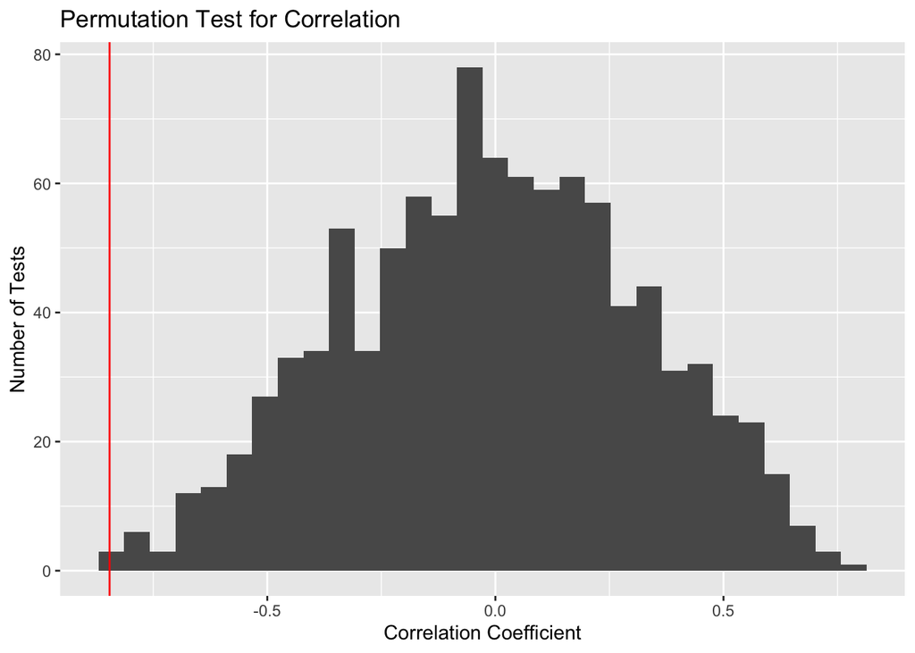

```r
USA <- co2_and_pump %>% filter(country == "United States")

perm_test_cor_team <- numeric(1000)

for(i in seq_along(perm_test_cor_team)){
  # Randomize one of variables of interest:
  s <- sample(USA$`CO2 Emissions (Tonnes/person)`)
  # Find the correlation between the un-randomized vector and the randomized vector
  perm_test_cor_team[i] <- cor(USA$`Pump Price ($/L)`,s)
}
USA_cor <- filter(cor_by_country,country == 'United States')$cor
ggplot(tibble(perm_test_cor_team),aes(perm_test_cor_team))+geom_histogram(bins = 30)+
  geom_vline(xintercept = USA_cor, color='red')+
  ggtitle("Permutation Test for Correlation")+
  ylab("Number of Tests")+
  xlab("Correlation Coefficient")
```

Our result is at a very low percentile of the test data, so we conclude that our result is significant: in the US, there is a strong negative correlation between gas price and CO2 emissions.

```r
sum(perm_test_cor_team < USA_cor)/length(perm_test_cor_team)
```

```
## [1] 0
```

We found that correlations range across the full spectrum of values: in EU countries and the US, we see a strong negative correlation. As gas prices go down, CO2 emissions rise. In some Asian/African countries, we see the opposite; higher gas prices go along with higher emissions. Additionally, there are countries which have little to no correlation between the two variables as well.

It seems reasonable to conclude that countries with a strong negative correlation have a larger proportion of their co2 emissions from car/truck travel. Countries with a strong positive correlation have some other primary contributor to their co2 emissions.

## Individual Sections

### Andrew

Is there a correlation between GDP and total amount of energy used by the country? I will only be checking for countries that are growing (postive GDP) because there are a lot of odd outlyers when taking in account negative values.

In order to map the function will be displaying the mean of both values. The significance of studying this is to determine whether or not countries base their energy consumption off of how their economy is growing.

```r
ener <- read_csv("energy_production_total.csv")

gdp <- read_csv("gdp_total_yearly_growth.csv")

ener <- ener%>%
  gather('1960':'2010', key = 'year', value = "Energy Cost")%>%
  filter(!is.na(`Energy Cost`))

gdp <- gdp%>%
  gather('1960':'2010', key = 'year', value = "GDP")%>%
  select('year','GDP','country')

gdp_pos <- gdp %>%
  filter(`GDP` > 0)
```

I will use an inner join to put the two together in order to study the correlation.

```r
combine <- gdp_pos %>% inner_join(ener, by = c('country','year'))
```

Map function: My use of the map function is to determine the mean GDP and energy cost over a global scale. This function takes GDP and Energy Cost which are the two columns we want to study and takes their overall mean. Looking at these statistics will us to see what the average growing country uses in energy compared to the amount their economy has grown.

```r
combine %>%
  select(`GDP`, `Energy Cost`)%>%
  map(mean)
```

```
## $GDP
## [1] 5.413993
##
## $`Energy Cost`
## [1] 68211.24
```

Null Hypothesis: There is no correlation between GDP and Energy Cost the correlation coefficient will be close zero.

Alternate Hypothesis: There will be strong correlation between the GDP and Energy Cost?

This function will run through and randomize the GDP and test how it correlates to the Energy Cost.

```r
perm_test_andrew <- numeric(1000)

for(i in seq_along(perm_test_andrew)){

  and <- sample(combine$`GDP`)

  perm_test_andrew[i] <- cor(combine$`Energy Cost`, and)
}

corre <- cor(x = combine$`GDP`, y = combine$`Energy Cost`)
```

This displays the correlation and also shows what percentiles the correlation resulted in.

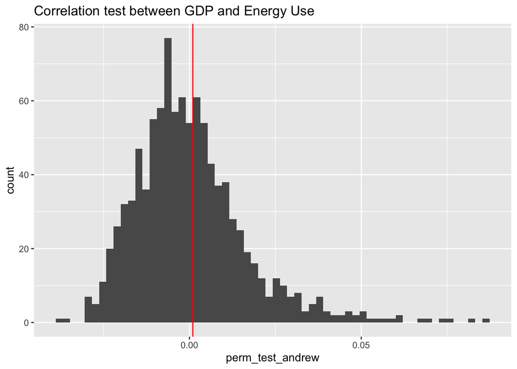

```r
ggplot(tibble(perm_test_andrew),mapping = aes(perm_test_andrew))+
  geom_histogram(bins = 60)+
  geom_vline(xintercept = corre, color='red')+
  ggtitle("Correlation test between GDP and Energy Use")
```

```r
percentiles_cor_test <- ecdf(perm_test_andrew)
percentiles_cor_test(corre)
```

```
## [1] 0.581
```

```r
range(perm_test_andrew)
```

```
## [1] -0.03825447  0.08597237
```

This is used to test the percentiles and the range of values in the perm test.

As we can tell from these values there is absolutely no significance in tgis correlation so we must accept the NULL hypothesis.

### Brian

What is the correlation between gas prices and co2 emissions on a global scale?

For measuring correlations, the pearson correlation coefficient seemed like the natural choice.

Using a map function with the correlation coefficient doesn’t work as easily as some other summary statistics. The nest function gives us a list of tibbles, then correlation is calculated using the map function in a mutate for each tibble in the list. Finally, unnest drops all the columns except the calculated correlation and any grouping variables used. The code was referenced from [here](https://community.rstudio.com/t/how-to-use-map-with-cor/6509).

```r
(act_cor <- co2_and_pump %>%
#  group_by(country) %>%
  nest() %>%
  mutate(cor = map(data, ~cor(.x$`CO2 Emissions (Tonnes/person)`, .x$`Pump Price ($/L)`))) %>%
  unnest(cor, .drop = TRUE))
```

```
## # A tibble: 1 x 1
##       cor
##     <dbl>
## 1 -0.0982
```

For finding a single correlation, using the columns directly in the cor function is much more straight forward. However, this method does yield the same result, and can be expanded to the grouped case, as in the team section.

The null hypothesis is that no correlation exists: the correlation coefficient is 0. The alternate hypothesis is that some correlation exists, so the correlation coefficient is non-zero.

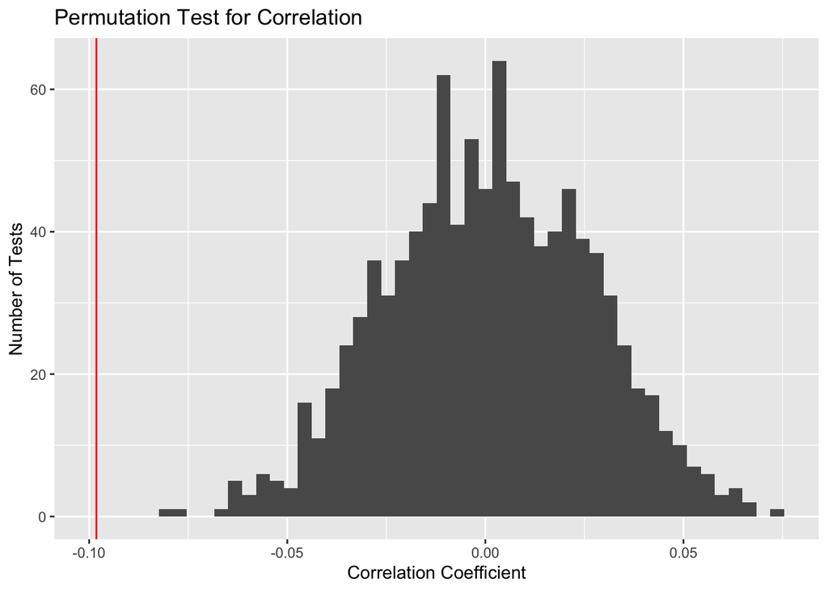

```r
perm_test_cor <- numeric(1000)

for(i in seq_along(perm_test_cor)){
  # Randomize one of variables of interest:
  s <- sample(co2_and_pump$`CO2 Emissions (Tonnes/person)`)
  # Find the correlation between the un-randomized vector and the randomized vector
  perm_test_cor[i] <- cor(co2_and_pump$`Pump Price ($/L)`,s)
}

ggplot(tibble(perm_test_cor),aes(perm_test_cor))+geom_histogram(bins = 50)+
  geom_vline(xintercept = act_cor$cor, color='red')+
  ggtitle("Permutation Test for Correlation")+
  ylab("Number of Tests")+
  xlab("Correlation Coefficient")
```

The percentile of the actual correlation:

```r
sum(act_cor$cor > perm_test_cor)/length(perm_test_cor)
```

```
## [1] 0
```

Since our result is at the 0th percentile of the permutation tests, we reject the null hypothesis that no correlation exists, in favor of the alternate hypothesis that some correlation exists.

While our calculated correlation appears to be a significant result, the actual value itself is quite small: -.1. This result was fairly surprising to me, as I anticipated a much stronger correlation. This lead to the formulation of the team question, where we found the correlations vary greatly between different countries. Thus, while the worldwide average correlation is very weak, this is because individual countries range across the entire spectrum of positive and negative correlations.

### Charles

Is there any correlation between the sex ratio of populations and the quantity of suicides? My interest is to take countries with ‘suicide crises’ (specifically Japan) and determine if the populations at the highest risk of suicide are those with a disproportionate amount of men or women. The majority of suicides occur between 15 and 49 years of age, so this is the data I will be taking into consideration.

```r
suicides_100k <- read_csv("suicide_per_100000_people.csv")
sex_ratio <- read_csv("sex_ratio_15_49_years.csv")

suicides_100k <- suicides_100k %>%
  gather(`1950`:`2016`,key='year',value='Suicides (per 100k people)') %>%
  filter(!is.na(`Suicides (per 100k people)`) & year < 2016)

sex_ratio <- sex_ratio %>%
  gather(`1950`:`2100`,key='year',value='Male/Female Ratio') %>%
  filter(!is.na(`Male/Female Ratio`) & year < 2016)

suicide_plus_ratio <- sex_ratio %>%
  inner_join(suicides_100k, by = c('country','year'))

suicide_plus_ratio %>% filter(country == 'Japan')
```

```
## # A tibble: 14 x 4
##    country year  `Male/Female Ratio` `Suicides (per 100k people)`
##    <chr>   <chr>               <dbl>                        <dbl>
##  1 Japan   1950                 93.6                         24.4
##  2 Japan   1955                 94.3                         28.1
##  3 Japan   1960                 95.4                         23.2
##  4 Japan   1965                 97.3                         15.8
##  5 Japan   1970                 99.5                         15.5
##  6 Japan   1975                102                           17.6
##  7 Japan   1980                103                           16.5
##  8 Japan   1985                103                           17.1
##  9 Japan   1990                103                           13.4
## 10 Japan   1995                104                           13.4
## 11 Japan   2000                104                           18.2
## 12 Japan   2005                104                           18.8
## 13 Japan   2010                104                           18.3
## 14 Japan   2015                104                           14.5
```

The map formula that I’ll use will be to find the median amount of suicides and the median male/female ratio of the population as well as the means of those values.

```r
suicide_plus_ratio %>% select(`Suicides (per 100k people)`, `Male/Female Ratio`) %>% map_dbl(median)
```

```
## Suicides (per 100k people)          Male/Female Ratio
##                      10.15                     102.00
```

```r
suicide_plus_ratio %>% select(`Suicides (per 100k people)`, `Male/Female Ratio`) %>% map_dbl(mean)
```

```
## Suicides (per 100k people)          Male/Female Ratio
##                   11.45024                  101.85765
```

The null hypothesis is that there is no correlation between the Male/Female ratio of a population and the proportion of suicides per 100,000 people.

```r
tests <- numeric(1000)

for(i in 1:1000){
  randomized <- sample(suicide_plus_ratio$`Male/Female Ratio`)
  tests[i] <- cor(suicide_plus_ratio$`Suicides (per 100k people)`, randomized)
}

correlation <- cor(x=suicide_plus_ratio$`Male/Female Ratio`,y=suicide_plus_ratio$`Suicides (per 100k people)`) # -0.1058622
```

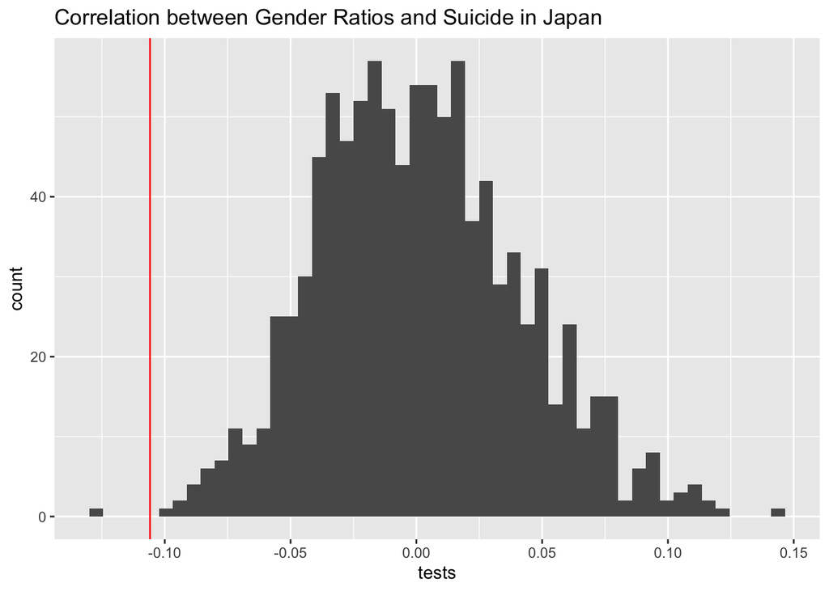

```r
ggplot(tibble(tests),aes(tests))+geom_histogram(bins = 50)+
  geom_vline(xintercept = correlation, color='red')+
  ggtitle("Correlation between Gender Ratios and Suicide in Japan")
```

the percentile where the real data summary falls in the distribution (i.e., step 6 in “Permutation Test Review”),

```r
percentile <- ecdf(tests)
percentile(correlation)
```

```
## [1] 0.001
```

```r
mean(percentile(tests))
```

```
## [1] 0.5005
```

### Clint

Is there a correlation between child mortality rate(# deaths per 1000 births) and fertility (average # of births per woman)?

In order to answer that question I’ll be testing to see if the correlation between the 75 countries that ranked in the top 50 or bottom 50 in both birthrate and mortality is statistically significant.

```r
child_mort <- read_csv("child_mortality_0_5_year_olds_dying_per_1000_born.csv")

birthrate <- read_csv("children_per_woman_total_fertility.csv")

child_mort <- child_mort%>%
  gather('1800':'2018', key = 'year', value = "Child Mortality (# of Deaths per Thousand Births")

birthrate <- birthrate%>%
  gather('1800':'2018', key = 'year', value = "Birthrate (# of Children per woman)")

mort_2018 <- child_mort%>%
  filter(year == "2018", !is.na(`Child Mortality (# of Deaths per Thousand Births`))%>%
  arrange(desc(`Child Mortality (# of Deaths per Thousand Births`))

birth_2018 <- birthrate%>%
  filter(year == "2018",!is.na(`Birthrate (# of Children per woman)`))%>%
  arrange(desc(`Birthrate (# of Children per woman)`))
```

```r
top_mort <- mort_2018%>%
  filter(`Child Mortality (# of Deaths per Thousand Births` >= 42.90)

bottom_mort <- mort_2018%>%
  filter(mort_2018$`Child Mortality (# of Deaths per Thousand Births` <= 7.97)

top_birth <- birth_2018%>%
  filter(`Birthrate (# of Children per woman)` >= 3.56)

bottom_birth <-birth_2018%>%
  filter(`Birthrate (# of Children per woman)` <= 1.76)

high_and_low_mort <- top_mort %>% full_join(bottom_mort)

high_and_low_birth <- top_birth %>% full_join(bottom_birth)

combined_data <- high_and_low_birth%>% inner_join(high_and_low_mort, by = c('country','year'))
```

Map function: Map function: My use of the map function is to determine the mean birthrate and child mortality rate for all 75 selected countries in the combined dataset. What this map function is doing is taking the two remaining collumns, which are bothof the type double and getting the mean value of both collumns. In a larger dataset it would still get the means of each collumns

```r
combined_data %>%
  select(`Birthrate (# of Children per woman)`, `Child Mortality (# of Deaths per Thousand Births`)%>%
  map_dbl(mean)
```

```
##              Birthrate (# of Children per woman)
##                                         3.290667
## Child Mortality (# of Deaths per Thousand Births
##                                        41.985467
```

Null Hypothesis: There is no correlation between Birthrate and Child Mortality, the correlation coefficient will be zero. Alternate Hypothesis: There will be a statistically significant correlation between Birthrate and Child Mortality, the real correlation will fall in the top 95th percent or bottom 5th percentile of my permutation test.

```r
perm_test_clint <- numeric(1000)

for(i in seq_along(perm_test_clint)){
  sam <- sample(combined_data$`Birthrate (# of Children per woman)`)
  perm_test_clint[i] <- cor(combined_data$`Child Mortality (# of Deaths per Thousand Births`,sam)
}
```

```r
real_cor <- cor(x = combined_data$`Birthrate (# of Children per woman)`,y = combined_data$`Child Mortality (# of Deaths per Thousand Births`) # 0.927
```

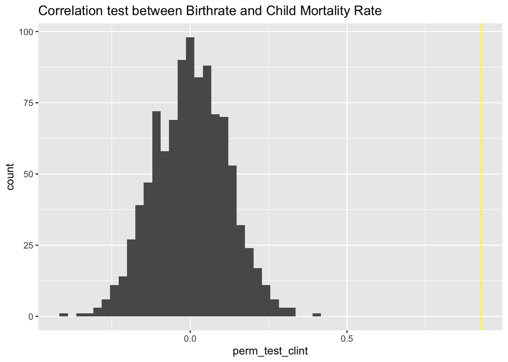

```r
ggplot(tibble(perm_test_clint),aes(perm_test_clint))+geom_histogram(bins = 50)+
  geom_vline(xintercept = real_cor, color='yellow')+
  ggtitle("Correlation test between Birthrate and Child Mortality Rate")
```

```r
percentiles_cor_test <- ecdf(perm_test_clint)
percentiles_cor_test(real_cor) #1
```

```
## [1] 1
```

```r
range(perm_test_clint) #-0.337, 0.356
```

```
## [1] -0.3918162  0.3972260
```

From my perumation test I can determine that the correlation between Child Mortality and birthrate is statistically significant because the actual corrlation was more than double andy observed random correlation and therefore fell in the 100th percentile of the correlation test.

From this we can conlcude that as Child Mortality rise Birthrate also rises, and the opposite is also true. This would make sense logically because if more children are dying before the age of 5 then more children would need to be born to even maintain the similar real Birthrate as other countries.